# empirical-fdr-comparison

June 11, 2022

# Simulation Experiment Recipe

## Objectives

**NOTE**: The experiments presented herein are a subset of [those](https://github.com/PhilBoileau/pub_uniCATE) described in [“A Flexible Approach for Predictive Biomarker Discovery” (P. Boileau, et al. 2022)](https://arxiv.org/abs/2205.01285). This subset was adapted by the original author for a case study of the R package [`simChef`](https://yu-group.github.io/simChef). To reproduce this case study and documentation, please see the repository simChef-case-study.

### Introduction

An endeavor central to precision medicine is predictive biomarker discovery; they define patient sub-populations which stand to benefit most, or least, from a given treatment. The identification of these biomarkers can be the byproduct of the related but fundamentally different task of treatment rule estimation, but often with high false discovery rates.

In synthetic and real-world data-inspired simulation settings to emulate randomized control trials with moderate and high-dimensional covariate vectors, we study a proposed predictive biomarker method, uniCATE. The objectives of this simulation study are:

1. Evaluate the proposed method as an estimator of a parameter for directly assessing the importance of potentially predictive biomarkers.
2. Examine the empirical behavior of the proposed method as the sample size $n$ grows to determine its correspondence to asymptotic results.
3. Study the statistical robustness of the proposed method under a number of misspecified nuisance parameter estimation scenarios.

This work is motivated by the need to identify predictive biomarkers in clinical trials. Of particular interest is their detection for drug target discovery and diagnostic assay development. The former requires the identification of biomarkers causally related to the outcome of interest, whereas the latter seeks a small set of strongly predictive biomarkers. We therefore focus on these applications throughout the simulation study.

### Notation

Consider $n$ identically and independently distributed random vectors $X_i = (W_i, A_i, Y^{(1)}_i, Y^{(0)}_i) \sim P_X$, $i = 1, \ldots, n$, corresponding to complete but unobserved data generated by participants in an idealized randomized control trial or observational study, where:

- $V$: pre-treatment covariates, such as location and income, of dimension $p$.
- $B$: pre-treatment biomarkers, such as gene expression data, of dimension $q$.
- $W = (V, B)$: a $(q+p)$-length random vector.
- $A$: a binary random variable representing a treatment assignment.
- $Y^{(1)}$ and $Y^{(0)}$: partially observed random variables corresponding to the potential outcomes of clinical interest under both treatment and control conditions, respectively, for each patient.
- $P_X$: The unknown data-generating distribution of the full data $(W, A, Y^{(0)}, Y^{(1)})$.
- $Y = AY^{(1)} + (1-A)Y^{(0)}$: observed outcomes where $Y_i = Y_i(1)$ if patient $i$ received treatment, and $Y_i = Y_i(0)$ otherwise.
- $P_0$: The unknown data-generating distribution of the observed data $(W, A, Y)$.
- $P_n$: The observed empirical distribution of a sample of size $n$ drawn from $P_0$.

### Clinically predictive biomarker importance parameter

Clinically relevant predictive biomarkers are often those that have a strong influence on the outcome of interest on the absolute scale. As such, an ideal target of inference when these outcomes are continuous and the number of covariates small is the CATE conditioning on the set of biomarkers:

$$\begin{equation*} \mathbb{E}_{P_X}\left[ Y^{(1)} - Y^{(0)} \big| B = b \right].\end{equation*}$$

Accurate and interpretable estimation of this parameter is generally challengingwhen $p$ is large, preventing the accurate recovery of predictive biomarkers.

Indexing the biomarkers of by $j = 1, \ldots, p$, such that $B = (B_{1}, \ldots, B_{p})$, centering them such that $\mathbb{E}_{P_X}[B_{j}] = 0$, and assuming that $\mathbb{E}_{P_X}[B^2_{j}] > 0$, we instead target the full-data variable importance parameter $\Psi^F(P_X) = (\Psi^F_1(P_X), \ldots, \Psi_p^F(P_X))$ where

$$\begin{equation*} \Psi_{j}^F(P_X) \equiv \frac{\mathbb{E}_{P_X}\left[\left(Y^{(1)} - Y^{(0)}\right)B_{j}\right]} {\mathbb{E}_{P_X}\left[B_{j}^2\right]}.\end{equation*}$$

Under the assumption that the mean difference in potential outcomes admits a linear form when conditioning on any given $B_j$, $\Psi^F(P_X)$ is the vector of expected simple linear regression coefficients produced by regressing the difference in potential outcomes against each biomarker. While the true relationship between the difference of potential outcomes and a predictive biomarker is almost surely nonlinear, $\Psi^F(P_X)$ is a generally informative target of inference. Biomarkers with the largest absolute values in $\Psi^F(P_X)$ generally modify the effect of treatment the most.

With assumptions of no unmeasured confounding and overlapping treatment support in which observations may be assigned to either treatment condition regardless of covariates, we have

$$\begin{equation} \begin{split} \Psi_j(P_0) & \equiv \frac{\mathbb{E}_{P_0}\left[\left(\bar{Q}_0(1, W) - \bar{Q}_0(0, W)\right)B_{j}\right]} {\mathbb{E}_{P_0}\left[B_{j}^2\right]} \\ & = \Psi_j^F(P_X) \end{split}\end{equation}$$

where $\bar{Q}_0(a, w) \equiv \mathbb{E}_{P_0}[Y|A = a, W = w]$ is the conditional outcome regression function, the treatment assignment mechanism is $g_0(a, w) \equiv \mathbb{P}_{P_0}[A = a | W = w]$, $\mathbb{E}_{P_0}[B_{j}] = 0$, and $\mathbb{E}_{P_0}[B^2_{j}] > 0$.

The parameter $\Psi_j(P_0)$ provides a measure of predictive biomarker importance which is the target of the proposed method, uniCATE, described within.

## Data Generation

LM with TEM

**Function**

```
## function (n = 125, cov_mat = diag(1, nrow = 100))
## {
##     beta_main <- c(rep(2, 20), rep(0, 80))
##     beta_0 <- rep(0, 100)
##     beta_1 <- c(rep(5, 50), rep(0, 50))
##     W <- MASS::mvrnorm(n = n, mu = rep(0, 100), Sigma = cov_mat)
##     colnames(W) <- paste0("W", seq_len(100))
##     A <- ifelse(runif(n) < 0.5, 0, 1)
##     epsilon_0 <- rnorm(n = n, mean = 0, sd = 0.5)
##     epsilon_1 <- rnorm(n = n, mean = 0, sd = 0.5)
##     W_t <- t(W)
##     main_effects <- crossprod(W_t, beta_main)
##     Y_0 <- as.vector(main_effects + crossprod(W_t, beta_0) +
##         epsilon_0)
##     Y_1 <- as.vector(main_effects + crossprod(W_t, beta_1) +
##         epsilon_1)
##     Y <- ifelse(A == 0, Y_0, Y_1)
##     sample_list <- list(Y = Y, A = A, W = W)
##     return(sample_list)
## }
```

**Input Parameters**

```
## list()
```

Kinked with TEM

**Function**

```
## function (n = 125, cov_mat = diag(1, nrow = 100))
## {
##     beta_tem <- c(rep(10, 50), rep(0, 50))
##     W <- MASS::mvrnorm(n = n, mu = rep(0, 100), Sigma = cov_mat)
##     colnames(W) <- paste0("W", seq_len(100))
##     A <- ifelse(runif(n) < 0.5, 0, 1)
##     epsilon_1 <- rnorm(n = n, mean = 0, sd = 0.5)
##     W_t <- t(W)
##     Y_1 <- as.vector(crossprod(W_t, beta_tem) + epsilon_1)
##     epsilon_0 <- rnorm(n = n, mean = 0, sd = 0.5)
##     W_mod <- W[, 1:50]
##     W_mod[W_mod < 0] <- 0
##     W_mod_t <- t(cbind(W_mod, W[, 51:100]))
##     Y_0 <- as.vector(crossprod(W_mod_t, beta_tem) + epsilon_0)
##     Y <- ifelse(A == 0, Y_0, Y_1)
##     sample_list <- list(Y = Y, A = A, W = W)
##     return(sample_list)
## }
```

**Input Parameters**

```
## list()
```

NLM with TEM

**Function**

```
## function (n = 125, cov_mat = diag(1, nrow = 100))
## {
##     beta_main <- c(rep(1, 20), rep(0, 80))
##     beta_0 <- rep(0, 100)
##     beta_1 <- c(rep(5, 50), rep(0, 50))
##     W <- MASS::mvrnorm(n = n, mu = rep(0, 100), Sigma = cov_mat)
##     colnames(W) <- paste0("W", seq_len(100))
##     A <- ifelse(runif(n) < 0.5, 0, 1)
##     epsilon_0 <- rnorm(n = n, mean = 0, sd = 0.5)
##     epsilon_1 <- rnorm(n = n, mean = 0, sd = 0.5)
##     W_t <- t(W)
##     main_effects <- rowSums(exp(abs(t((W_t * beta_main)))))
##     Y_0 <- as.vector(main_effects + crossprod(W_t, beta_0) +
##         epsilon_0)
##     Y_1 <- as.vector(main_effects + crossprod(W_t, beta_1) +
##         epsilon_1)
##     Y <- ifelse(A == 0, Y_0, Y_1)
##     sample_list <- list(Y = Y, A = A, W = W)
##     return(sample_list)
## }
```

**Input Parameters**

```
## list()
```

## Methods and Evaluation

### Methods

uniCATE (LASSO)

We propose a cross-validated estimator that uses all available data. Begin by randomly partitioning the $n$ observations of $P_n$ into $K$ independent validation sets $P_{n, 1}^1, \ldots, P_{n, K}^1$ of approximately equal size. For $k=1,\ldots, K$, define the training set as, in a slight abuse of notation, $P_{n, k}^0 = P_n \setminus P_{n,k}^1$. Then the cross-validated estimator of $\Psi_j(P_0)$ is defined as:

$$\begin{equation} \Psi_j^{(\text{CV})}(P_n) = \frac{1}{K} \sum_{k=1}^K \frac{\sum_{i=1}^n I(O_i \in P_{n, k}^1)\tilde{T}(O_i; P_{n,k}^0)B_{ij}} {\sum_{i=1}^n I(O_i \in P_{n, k}^1) B_{ij}^2}.\end{equation}$$

**Function**

```
## function (Y, A, W, use_sl = FALSE)
## {
##     sample_tbl <- tibble::tibble(Y = Y, A = A)
##     sample_tbl <- dplyr::bind_cols(sample_tbl, W)
##     biomarker_names <- colnames(W)
##     propensity_score_ls <- list(`1` = 0.5, `0` = 0.5)
##     if (use_sl) {
##         interactions <- lapply(biomarker_names, function(b) c("A",
##             b))
##         lrnr_interactions <- sl3::Lrnr_define_interactions$new(interactions)
##         lrnr_lasso <- sl3::make_learner(sl3::Pipeline, lrnr_interactions,
##             sl3::Lrnr_glmnet$new())
##         lrnr_enet <- sl3::make_learner(sl3::Pipeline, lrnr_interactions,
##             sl3::Lrnr_glmnet$new(alpha = 0.5))
##         lrnr_ridge <- sl3::make_learner(sl3::Pipeline, lrnr_interactions,
##             sl3::Lrnr_glmnet$new(alpha = 0))
##         lrnr_spline <- sl3::make_learner(sl3::Pipeline, lrnr_interactions,
##             sl3::Lrnr_polspline$new())
##         lrnr_rf <- sl3::make_learner(sl3::Pipeline, lrnr_interactions,
##             sl3::Lrnr_ranger$new())
##         lrnr_mean <- sl3::Lrnr_mean$new()
##         learner_library <- sl3::make_learner(sl3::Stack, lrnr_spline,
##             lrnr_lasso, lrnr_enet, lrnr_ridge, lrnr_rf, lrnr_mean)
##         super_learner <- sl3::Lrnr_sl$new(learners = learner_library,
##             metalearner = sl3::make_learner(sl3::Lrnr_nnls))
##     }
##     else {
##         super_learner <- NULL
##     }
##     unicate_tbl <- uniCATE::unicate(data = sample_tbl, outcome = "Y",
##         treatment = "A", covariates = biomarker_names, biomarkers = biomarker_names,
##         propensity_score_ls = propensity_score_ls, v_folds = 5L,
##         super_learner = super_learner)
##     tems <- unicate_tbl %>% dplyr::filter(p_value_bh <= 0.05) %>%
##         dplyr::pull(biomarker)
##     tems <- list(tems = tems)
##     return(tems)
## }
```

**Input Parameters**

```
## $use_sl
## [1] FALSE
```

Modified Covariates

**Function**

```
## function (Y, A, W)
## {
##     propensity_func <- function(x, trt) 0.5
##     mod_cov <- personalized::fit.subgroup(x = W, y = Y, trt = A,
##         propensity.func = propensity_func, loss = "sq_loss_lasso",
##         nfolds = 10)
##     coefs <- mod_cov$coefficients[paste0("W", seq_len(100)),
##         ]
##     tems <- names(coefs[which(coefs != 0)])
##     tems <- list(tems = tems)
##     return(tems)
## }
```

**Input Parameters**

```
## list()
```

Augmented Modified Covariates

**Function**

```
## function (Y, A, W)
## {
##     propensity_func <- function(x, trt) 0.5
##     augment_func <- function(x, y) {
##         df.x <- data.frame(x)
##         form <- eval(paste(" ~ 1 + ", paste(colnames(df.x), collapse = " + ")))
##         mm <- model.matrix(as.formula(form), data = df.x)
##         cvmod <- glmnet::cv.glmnet(y = y, x = mm, nfolds = 10)
##         predictions <- predict(cvmod, newx = mm, s = "lambda.min")
##         predictions
##     }
##     aug_mod_cov <- personalized::fit.subgroup(x = W, y = Y, trt = A,
##         propensity.func = propensity_func, loss = "sq_loss_lasso",
##         augment.func = augment_func, nfolds = 10)
##     coefs <- aug_mod_cov$coefficients[paste0("W", seq_len(100)),
##         ]
##     tems <- names(coefs[which(coefs != 0)])
##     tems <- list(tems = tems)
##     return(tems)
## }
```

**Input Parameters**

```
## list()
```

### Evaluation

Empirical FDR

**Function**

```
## function (fit_results)
## {
##     group_vars <- c(".dgp_name", ".method_name", "n")
##     eval_out <- fit_results %>% mutate(fdp = purrr::map_dbl(tems,
##         fdp_fun)) %>% dplyr::group_by(dplyr::across({
##         {
##             group_vars
##         }
##     })) %>% summarize(fdr = mean(fdp), .groups = "drop")
##     return(eval_out)
## }
```

**Input Parameters**

```
## list()
```

Empirical TPR

**Function**

```
## function (fit_results)
## {
##     group_vars <- c(".dgp_name", ".method_name", "n")
##     eval_out <- fit_results %>% mutate(tpp = purrr::map_dbl(tems,
##         tpp_fun)) %>% dplyr::group_by(dplyr::across({
##         {
##             group_vars
##         }
##     })) %>% summarize(tpr = mean(tpp), .groups = "drop")
##     return(eval_out)
## }
```

**Input Parameters**

```
## list()
```

Empirical TNR

**Function**

```
## function (fit_results)
## {
##     group_vars <- c(".dgp_name", ".method_name", "n")
##     eval_out <- fit_results %>% mutate(tnp = purrr::map_dbl(tems,
##         tnp_fun)) %>% dplyr::group_by(dplyr::across({
##         {
##             group_vars
##         }
##     })) %>% summarize(tnr = mean(tnp), .groups = "drop")
##     return(eval_out)
## }
```

**Input Parameters**

```
## list()
```

## Visualizations

Summary Plot

**Function**

```
## function (eval_results)
## {
##     emp_fdr_tbl <- eval_results$`Empirical FDR` %>% dplyr::mutate(metric = "FDR",
##         value = fdr, yintercept = 0.05) %>% dplyr::select(-fdr)
##     emp_tpr_tbl <- eval_results$`Empirical TPR` %>% dplyr::mutate(metric = "TPR",
##         value = tpr, yintercept = NA) %>% dplyr::select(-tpr)
##     emp_tnr_tbl <- eval_results$`Empirical TNR` %>% dplyr::mutate(metric = "TNR",
##         value = tnr, yintercept = NA) %>% dplyr::select(-tnr)
##     comb_tbl <- bind_rows(emp_fdr_tbl, emp_tpr_tbl, emp_tnr_tbl)
##     plt <- ggplot2::ggplot(comb_tbl) + ggplot2::aes(x = n, y = value,
##         colour = as.factor(.method_name)) + ggplot2::geom_point(alpha = 0.7) +
##         ggplot2::geom_line(alpha = 0.7) + ggplot2::geom_hline(aes(yintercept = yintercept),
##         colour = "red", linetype = 2, alpha = 0.5) + ggplot2::facet_grid(cols = ggplot2::vars(.dgp_name),
##         rows = ggplot2::vars(metric)) + ggplot2::xlab("Sample Size") +
##         ggplot2::ylab("Value") + ggplot2::scale_colour_viridis_d(name = "Method",
##         option = "E", end = 0.8) + ggplot2::theme_bw()
##     return(plt)
## }
## <bytecode: 0x5625c56e1088>
```

**Input Parameters**

```
## list()
```

# LM with TEM-Kinked with TEM-NLM with TEM

## Varying n-n-n

### Empirical FDR

|  | .dgp_name | .method_name | n | fdr |
| --- | --- | --- | --- | --- |
| 1 | Kinked with TEM | Augmented Modified Covariates | 125.00 | 0.31 |
| 2 | Kinked with TEM | Augmented Modified Covariates | 250.00 | 0.29 |
| 3 | Kinked with TEM | Augmented Modified Covariates | 500.00 | 0.29 |
| 4 | Kinked with TEM | Modified Covariates | 125.00 | 0.33 |
| 5 | Kinked with TEM | Modified Covariates | 250.00 | 0.28 |
| 6 | Kinked with TEM | Modified Covariates | 500.00 | 0.26 |
| 7 | Kinked with TEM | uniCATE (LASSO) | 125.00 | 0.15 |
| 8 | Kinked with TEM | uniCATE (LASSO) | 250.00 | 0.04 |
| 9 | Kinked with TEM | uniCATE (LASSO) | 500.00 | 0.03 |
| 10 | LM with TEM | Augmented Modified Covariates | 125.00 | 0.30 |

[output cut: 17 more lines]

### Empirical TPR

|  | .dgp_name | .method_name | n | tpr |
| --- | --- | --- | --- | --- |
| 1 | Kinked with TEM | Augmented Modified Covariates | 125.00 | 0.09 |
| 2 | Kinked with TEM | Augmented Modified Covariates | 250.00 | 0.18 |
| 3 | Kinked with TEM | Augmented Modified Covariates | 500.00 | 0.49 |
| 4 | Kinked with TEM | Modified Covariates | 125.00 | 0.06 |
| 5 | Kinked with TEM | Modified Covariates | 250.00 | 0.05 |
| 6 | Kinked with TEM | Modified Covariates | 500.00 | 0.08 |
| 7 | Kinked with TEM | uniCATE (LASSO) | 125.00 | 0.01 |
| 8 | Kinked with TEM | uniCATE (LASSO) | 250.00 | 0.04 |
| 9 | Kinked with TEM | uniCATE (LASSO) | 500.00 | 0.37 |
| 10 | LM with TEM | Augmented Modified Covariates | 125.00 | 0.42 |

[output cut: 17 more lines]

### Empirical TNR

|  | .dgp_name | .method_name | n | tnr |
| --- | --- | --- | --- | --- |
| 1 | Kinked with TEM | Augmented Modified Covariates | 125.00 | 0.94 |
| 2 | Kinked with TEM | Augmented Modified Covariates | 250.00 | 0.89 |
| 3 | Kinked with TEM | Augmented Modified Covariates | 500.00 | 0.75 |
| 4 | Kinked with TEM | Modified Covariates | 125.00 | 0.95 |
| 5 | Kinked with TEM | Modified Covariates | 250.00 | 0.95 |
| 6 | Kinked with TEM | Modified Covariates | 500.00 | 0.95 |
| 7 | Kinked with TEM | uniCATE (LASSO) | 125.00 | 0.99 |
| 8 | Kinked with TEM | uniCATE (LASSO) | 250.00 | 1.00 |
| 9 | Kinked with TEM | uniCATE (LASSO) | 500.00 | 0.99 |
| 10 | LM with TEM | Augmented Modified Covariates | 125.00 | 0.78 |

[output cut: 17 more lines]

### Summary Plot

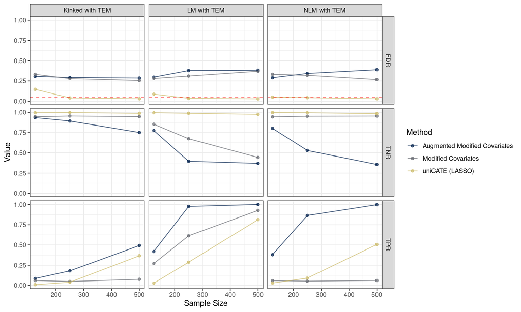

**Parameter Values**

```
## $dgp
## $dgp$`LM with TEM`
## $dgp$`LM with TEM`$n
## [1] 125 250 500
##
##
## $dgp$`Kinked with TEM`
## $dgp$`Kinked with TEM`$n
## [1] 125 250 500
##
##
## $dgp$`NLM with TEM`
## $dgp$`NLM with TEM`$n
## [1] 125 250 500
##
##
##
## $method
## list()
```